# DATASCI 385 - Experimental Methods

Lecture 24 - Integration of Research Findings

Danilo Freire

danilo.freire@emory.edu

Department of Data and Decision Sciences  
Emory University

# Hello, everyone! 😉

# Brief recap 📚

## Texts for discussion

- We discussed four papers:
  - Druckman et al. (2015) used a list experiment on athlete drug/alcohol use, showing significant underreporting compared to direct questions
  - Blair et al. (2014) compared list and endorsement experiments to measure support for NATO forces in Afghanistan
  - Rosenfeld et al. (2016) validated list experiments, endorsement experiments, and the randomised response technique (RRT) against Mississippi referendum results, finding RRT performed pretty well
  - Freire & Skarbek (2023) employed a conjoint experiment to understand attitudes towards lynching in Brazil

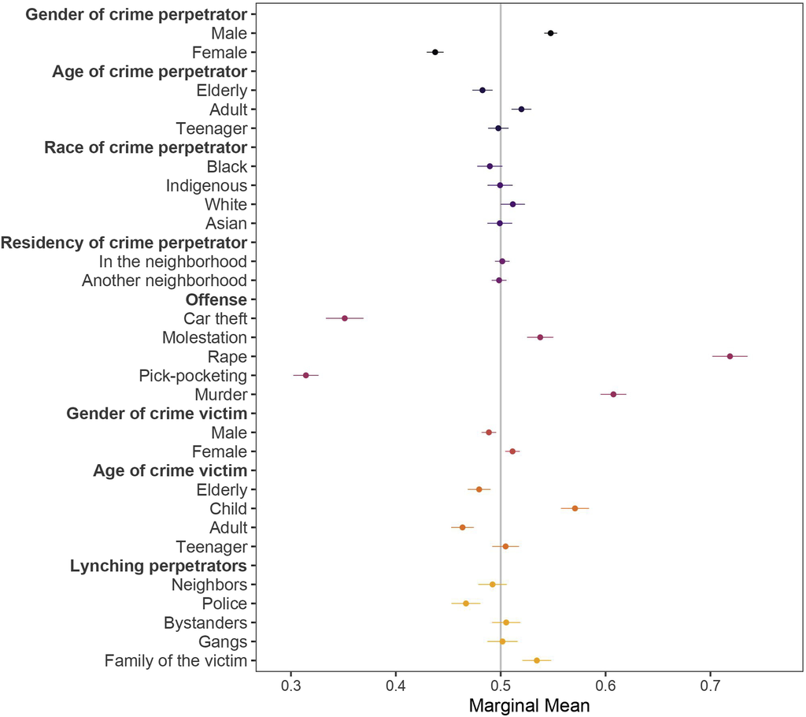

# Today’s plan 📅

## Integration of research findings

- Discuss the challenge of generalising experimental results
- Distinguish between Sample ATE (SATE) and Population ATE (PATE)
- Understand the calculation and interpretation of standard errors for the PATE
- Introduce a Bayesian framework for updating beliefs with new experimental evidence
- Consider how to incorporate potential bias (like sampling bias) into our analysis and uncertainty estimates
- Introduce meta-analysis as a technique for pooling results from multiple studies
- Examine the assumptions and limitations of common meta-analytic approaches

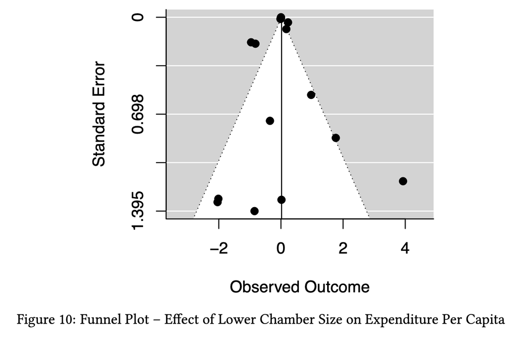

Source: [Freire et al (2022)](https://doi.org/10.1017/S0007123422000552)

# The challenge of generalisation 🤔

## Extrapolation from experiments

- Experiments yield estimates (like the SATE) specific to the sample, setting, treatment details, and time of the study
- However, research aims to answer broader questions:
  - How do these findings fit with existing literature?
  - What are the implications for theory?
  - What policy recommendations follow?
- Answering these requires extrapolation, that is, extending conclusions beyond the precise conditions of the experiment
- This process involves additional assumptions and some educated guesswork, moving away from the strong causal footing provided by randomisation

[figure not shown]

Source: [xkcd (2025)](https://xkcd.com/3042/)

## Uncertainty and bias

- Extrapolation can also introduce systematic bias:
  - Sampling bias: Convenience samples (common in experiments) might not represent the broader population of interest
  - Publication bias: Statistically significant or ‘interesting’ results are often more likely to be published, skewing the available literature
  - Contextual changes: Underlying conditions governing cause and effect might shift over time or across locations
  - Measurement bias: Variations in how outcomes are measured can lead to inconsistencies in reported effects
- Even a direct replication involves a new sample and potentially subtle contextual shifts

[figure not shown]

Source: [Nature (2016,](https://www.nature.com/articles/533452a) [2025)](https://www.nature.com/articles/d41586-024-04253-w)

## Verification vs. replication

- Verification: Taking the original data from a completed study and attempting to reproduce the reported statistical results.
  - Here, the goal is to check for clerical errors, understand the impact of specific analytical choices, and assess the sensitivity of results to different modelling decisions
- Replication: Conducting a *new* experiment that uses the same design (treatments, outcome measures, general procedures) as an earlier study, often in a similar setting with similar subjects
  - The goal is to assess the robustness and generalisability of the original finding

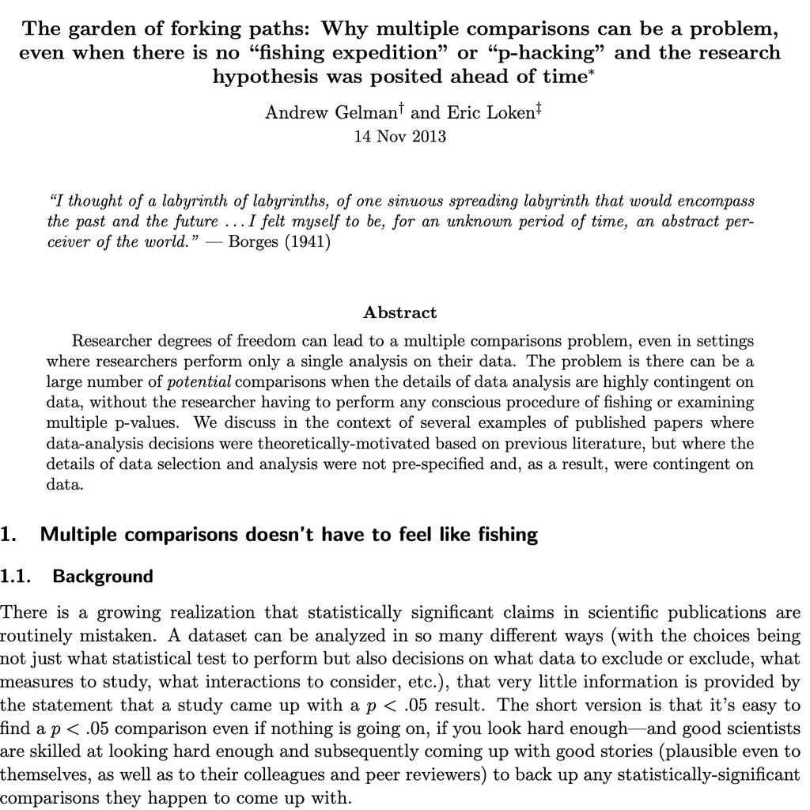

Source: [Gelman and Loken (2014)](https://sites.stat.columbia.edu/gelman/research/unpublished/p_hacking.pdf)

# Estimating population average treatment effects (PATE) 🌎

## From sample to population

- Sample Average Treatment Effect (SATE): Average causal effect specifically within the group of individuals included in our experiment
- Often, our real interest lies in the Population Average Treatment Effect (PATE): The average effect we would expect if the treatment were applied to the entire population from which our sample was drawn
- Replication studies (which involve drawing new samples) highlight the shift from considering only within-sample randomisation variability (for SATE) to considering sample-to-sample variability (for PATE)
- If subjects are selected via random sampling from a well-defined, large population, we can statistically estimate the PATE and quantify the uncertainty around that estimate
- This involves an additional layer of uncertainty compared to just estimating the SATE, because our specific sample might not perfectly mirror the population due to random chance
  - The standard error of the PATE is usually larger than that of the SATE, reflecting this added uncertainty

## Quantifying uncertainty

- Under ideal conditions (independent random sampling from a fixed, large population $N*$), the standard error of the estimated PATE ($SE(\widehat{PATE})$) is given by:

  $$SE(\widehat{PATE}) = \sqrt{ \frac{Var(Y_i(1))}{m} + \frac{Var(Y_i(0))}{N-m} } \quad$$
- $Var(Y_i(1))$ and $Var(Y_i(0))$ are the variances of potential outcomes in the population under treatment and control
- $m$ is the number of subjects in the treatment group, and $N-m$ is the number in the control group
- As you can see, the variance of both groups goes down as sample sizes increase, reducing the overall standard error
- However, these are typically estimated using the variances observed in the treatment and control groups of our sample
- This formula differs from the SATE standard error because it relies on population variances and, due to the assumption of a large population $N*$, the covariance between potential outcomes is assumed to be zero

# A Bayesian framework for interpretation 📈

## Updating beliefs with evidence

- Convenience samples tend to be clustered, drawing all of the subjects from a common location or period of time
- So we need a framework to reason about generalisation
- Because generalisation involves inference beyond the data at hand, a Bayesian approach is useful here
- Bayesian inference views probability as representing a subjective degree of belief about a hypothesis or parameter value
- The process involves the following steps:
  1. Starting with prior beliefs about the parameter (e.g., the PATE) before seeing the current study’s results
  2. Observing the evidence from the new experiment
  3. Using Bayes’ Rule to combine the prior beliefs and the evidence to form updated posterior beliefs
- This framework explicitly models how our understanding should rationally change as new information becomes available

## Priors and posteriors

### Characterising beliefs

- **Prior Beliefs**: Our knowledge or belief about a parameter (like the PATE) *before* considering the evidence from the current experiment
  - Often expressed as a probability distribution (e.g., assuming the PATE follows a normal distribution with a certain mean and variance)
  - The mean reflects the best guess, and the variance reflects the degree of prior uncertainty
  - Can be based on previous studies, theory, or expert judgement
- **Posterior Beliefs**: Our updated state of knowledge or belief *after* incorporating the evidence from the experiment
  - Also expressed as a probability distribution
  - Mathematically derived by combining the prior distribution and the likelihood of the observed data (which reflects the experimental result and its precision)
  - Represents a compromise (weighed average) between prior beliefs and the new evidence. Stronger priors or less precise evidence lead to smaller updates

## Bayes’ rule for discrete outcomes

### Updating beliefs about a hypothesis

- Imagine that we ran an RCT that gave us a statistically significant result and we want to update our belief about whether the treatment has a positive effect
- We have our hypothesis $H$ (the treatment has a positive effect) and evidence $E$ from an experiment (the result is statistically significant at the $0.05$ level)
- Bayes’ rule tells us how to update our belief in $H$ after observing $E$ (the posterior probability, $P(H|E)$):

  $$P(H|E) = \frac{P(E|H)P(H)}{P(E)} = \frac{P(E|H)P(H)}{P(E|H)P(H) + P(E|\neg H)(1-P(H))}$$
- The numerator, $P(E|H)P(H)$, represents the probability $E$ occurs assuming $H$ is true, multiplied by the probability $H$ is true in the first place
- Now we need $P(E)$, the total probability of seeing the evidence
- Why? $E$ can occur in two mutually exclusive ways: either $H$ is true or $H$ is false
- Thus, we have the denominator: $P(E|H)P(H) + P(E|\neg H)(1-P(H))$
- If $H$ was unlikely to begin with (low $P(H)$), you need very strong evidence (high $P(E|H)$) to believe it now
- Conversely, if $H$ was already very likely, even weak evidence can reinforce that belief

## Bayes’ rule for discrete outcomes

### Updating beliefs about a hypothesis

- To solve the equation, we need three components:
  - P(H): Our prior belief in $H$ before the experiment. Imagine we thought there was a 50/50 chance the treatment worked
  - P(E|H): The probability of observing evidence $E$ if $H$ is true (the statistical power of the test)
  - P(E|~H): The probability of observing $E$ if $H$ is false (Type I error rate, $0.05$)
- We can then plug these values into Bayes’ rule to get the updated (posterior) belief:

  $$P(H|E) = \frac{P(E|H)P(H)}{P(E|H)P(H) + P(E|\neg H)(1-P(H))}$$

  $$= \frac{0.45 \times 0.5}{0.45 \times 0.5 + 0.05 \times 0.5}$$
  $$= \frac{0.225}{0.225 + 0.025} = \frac{0.225}{0.25} = 0.90$$
- So after seeing a significant result, our belief that the treatment has a positive effect jumps from 50% to 90%!

## Bayesian updating with normal distributions

### Estimating a continuous parameter (PATE)

- Now let’s apply this to estimate a continuous parameter, the PATE, denoted $\tau$
- **Prior beliefs**: Assume our prior beliefs about $\tau$ can be represented by a normal distribution with mean $g$ (our best guess) and variance $\sigma^2_g$
- **Experimental result**: The experiment yields an estimate $x_e$ with a standard error $\sigma_{xe}$, so its variance is $\sigma^2_{xe}$
- **Likelihood**: Assuming the experimental estimate $x_e$ follows a normal sampling distribution centred on the true PATE ($\tau$), the likelihood is also normal (conjugate priors)
- **Posterior beliefs**: When both the prior and the likelihood are normal, the resulting posterior distribution for $\tau$ is also normal
- The mean and variance of this posterior distribution are calculated as a weighted average of the prior information and the experimental evidence, reflecting the relative precision of each
- We will now incorporate the possibility of bias in the experimental estimate of the PATE

## Visualising the Bayesian update

- Consider a simple case (initially ignoring bias):
  - Prior belief about PATE: Centred at $g=0$ with standard deviation $\sigma_g=2$ (variance $\sigma^2_g=4$)
  - Experimental result: Estimate $x_e=10$ with standard error $SE_{xe}=1$ (variance $\sigma^2_{xe}=1$)
- The Posterior belief about PATE will be:
  - A normal distribution
  - Centred between the prior mean ($0$) and the data ($10$)
  - More precise (smaller variance) than the prior in our example
- In this example, the posterior mean is $8$, and the posterior standard deviation is approximately $0.89$. The data, being more precise than the prior, pulls the posterior belief strongly towards it

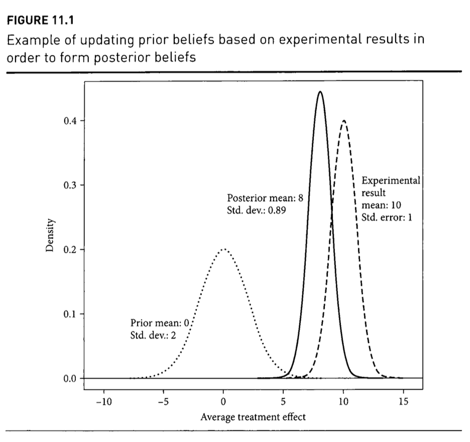

Source: FEDAI Figure 11.1. Prior (dotted), likelihood based on experimental result (dashed), and posterior (solid) distributions.

## Calculating the posterior (normal-normal case)

- It is often easier to work with precision, which is defined as the inverse of the variance: $\text{precision} = 1 / \sigma^2$
  - Small variance means low uncertainty and high precision
  - Large variance means the opposite: high uncertainty and low precision
  - Prior precision: $\rho_{prior} = 1 / \sigma^2_{prior}$
  - Data precision: $\rho_{data} = 1 / \sigma^2_{data}$
- The posterior precision is simply the sum of the prior and data precisions:
  $$\rho_{posterior} = \rho_{prior} + \rho_{data}$$
  - This addition reflects how combining information increases our overall certainty
- The posterior mean is a precision-weighted average of the prior mean and the data:
  $$\mu_{posterior} = \frac{\rho_{prior} \mu_{prior} + \rho_{data} x_e}{\rho_{posterior}} = \frac{(1/\sigma^2_{prior}) \mu_{prior} + (1/\sigma^2_{data}) x_e}{(1/\sigma^2_{prior}) + (1/\sigma^2_{data})}$$
  - Information sources with higher precision (lower variance) receive more weight in determining the final posterior belief
- The posterior variance is the inverse of the posterior precision: $\sigma^2_{posterior} = 1 / \rho_{posterior}$

## R code for Bayesian update (normal-normal)

- Let’s apply this to the example from Figure 11.1, calculating precisions first

```r
# Prior
prior_mean <- 0
prior_se <- 2
prior_var <- prior_se^2
# Prior precision
prior_precision <- 1 / prior_var

# Experimental data
data_mean <- 10
data_se <- 1
data_var <- data_se^2
# Calculate data precision
data_precision <- 1 / data_var

# Posterior precision
posterior_precision <- prior_precision + data_precision

# Posterior variance and SE
posterior_var <- 1 / posterior_precision
posterior_se <- sqrt(posterior_var)

# Posterior mean (precision-weighted average)
posterior_mean <- (prior_precision * prior_mean + data_precision * data_mean) / posterior_precision

# Print Results
cat("Prior Mean:", prior_mean, " Prior SE:", prior_se, " Prior Precision:", round(prior_precision, 2), "\n")
```

```
Prior Mean: 0  Prior SE: 2  Prior Precision: 0.25
```

```r
cat("Data Mean:", data_mean, "  Data SE:", data_se, "  Data Precision:", round(data_precision, 2), "\n")
```

```
Data Mean: 10   Data SE: 1   Data Precision: 1
```

```r
cat("Posterior Mean:", round(posterior_mean, 2), " Posterior SE:", round(posterior_se, 2), " Posterior Precision:", round(posterior_precision, 2), "\n")
```

```
Posterior Mean: 8  Posterior SE: 0.89  Posterior Precision: 1.25
```

## Incorporating potential bias

### When the experiment might be biased for PATE

- Now, let’s consider the more realistic scenario where our experiment might yield an unbiased estimate of the *Sample* ATE, but due to non-random sampling or other factors, it might be a biased estimate of the *Population* ATE ($\tau$)
- Let $B$ represent this potential sampling bias, such that the expected experimental result, given the true PATE $\tau$, is $\tau + B$
- We need to expand our Bayesian model to include prior beliefs about this bias term $B$
- Assume $B \sim N(\beta, \sigma^2_B)$, where $\beta$ is our prior belief about the bias and $\sigma^2_B$ is our uncertainty about it
- We typically assume that our prior beliefs about the true effect $\tau$ and the bias $B$ are independent

## Posterior mean and variance with bias

### Updating beliefs about PATE ($\tau$)

- We define the data’s effective precision for estimating $\tau$ as:

$$\rho_{effective\_data} = \frac{1}{\sigma^2_B + \sigma^2_{xe}}$$

- Higher uncertainty about the bias ($\sigma^2_B$) directly *reduces* the effective precision of the data
- Think of bias uncertainty as adding noise to $\tau$
- Researchers implicitly setting $\beta = 0$ and $\sigma^2_B = 0$ when extrapolating from convenience samples risk significant overconfidence
- The posterior mean becomes a weighted average using the prior precision ($\rho_{prior}$) and the data’s *effective* precision ($\rho_{effective\_data}$) as weights:

$$\mu_{posterior} = \frac{\rho_{prior} g + \rho_{effective\_data} (x_e - \beta)}{\rho_{prior} + \rho_{effective\_data}}$$

- The posterior variance also incorporates bias uncertainty, making the final belief less certain than if bias were ignored:

$$\sigma^2_{posterior} = \frac{1}{\rho_{prior} + \rho_{effective\_data}}$$

## R code for update with bias beliefs

- Now we add prior beliefs about the bias (mean `bias_mean` = $\beta$, se `bias_se` = $\sigma_B$) and test the impact of different levels of uncertainty about the bias on the posterior mean and variance

**R Code**

```r
calculate_posterior <- function(prior_mean, prior_se,
                                data_mean, data_se,
                                bias_mean, bias_se) {

  # Precisions for prior and data measurement
  prior_var <- prior_se^2
  prior_precision <- 1 / prior_var
  data_var <- data_se^2
  data_precision <- 1 / data_var # Precision of the measurement itself

  # Precision related to bias belief
  bias_var <- bias_se^2
  # Handle case where bias_se is 0 (certainty about bias) to avoid division by zero
  if (bias_var == 0) {
      bias_precision <- Inf
  } else {
      bias_precision <- 1 / bias_var # How certain are we about the bias value
  }


  # Calculate data's effective precision for estimating tau
  # Uncertainty about bias adds to the data's measurement variance
  total_data_uncertainty_variance <- bias_var + data_var
  if (total_data_uncertainty_variance == 0) { # Should only happen if bias_se=0 and data_se=0
      effective_data_precision <- Inf
  } else {
      effective_data_precision <- 1 / total_data_uncertainty_variance
  }


  # Calculate posterior precision (certainty about tau)
  posterior_precision <- prior_precision + effective_data_precision
  posterior_precision <- prior_precision + effective_data_precision

  # Calculate posterior variance and SE for tau
  if (posterior_precision == Inf) { # Handle certainty case
       posterior_var <- 0
  } else {
       posterior_var <- 1 / posterior_precision
  }
  posterior_se <- sqrt(posterior_var)

  # Calculate posterior mean for tau
  # Weighted average using prior precision and data's *effective* precision
  # Note: Data point is corrected by expected bias (data_mean - bias_mean)

   # Handle edge case of infinite precisions
  if (is.infinite(prior_precision) && is.infinite(effective_data_precision)) {
      # This case is ill-defined unless prior_mean equals (data_mean - bias_mean)
      # For simplicity, let's prioritize data if both are infinitely precise.
       posterior_mean <- data_mean - bias_mean
  } else if (is.infinite(prior_precision)) {
       posterior_mean <- prior_mean
  } else if (is.infinite(effective_data_precision)) {
      posterior_mean <- data_mean - bias_mean
  } else if (posterior_precision == 0) { # Both prior and effective data precision are 0 (infinite variance)
       posterior_mean <- NA # Undefined / Non-informative
  } else {
      posterior_mean <- (prior_precision * prior_mean +
                         effective_data_precision * (data_mean - bias_mean)) / posterior_precision
  }


  # Return results
  list(prior_mean = prior_mean, prior_se = prior_se, prior_precision = prior_precision,
       data_mean = data_mean, data_se = data_se, data_precision = data_precision,
       bias_mean = bias_mean, bias_se = bias_se, bias_precision = bias_precision,
       effective_data_precision = effective_data_precision,
       posterior_mean = posterior_mean, posterior_se = posterior_se, posterior_precision = posterior_precision)
}

# --- Example cases ---
# Base info from Fig 11.1
prior_mean_base <- 0
prior_se_base <- 2
data_mean_base <- 10
data_se_base <- 1

# Case A: Certainty of no bias (Bias SE = 0)
results_A <- calculate_posterior(prior_mean_base, prior_se_base, data_mean_base, data_se_base, bias_mean = 0, bias_se = 0)

# Case B: Moderate uncertainty about bias (Bias SE = 2)
results_B <- calculate_posterior(prior_mean_base, prior_se_base, data_mean_base, data_se_base, bias_mean = 0, bias_se = 2)

# Case C: High uncertainty about bias (Bias SE = 10)
results_C <- calculate_posterior(prior_mean_base, prior_se_base, data_mean_base, data_se_base, bias_mean = 0, bias_se = 10)

# --- Print results ---
print_results <- function(results, case_label) {
  cat("--- Case:", case_label, "---\n")
  cat(sprintf("Bias Beliefs: Mean=%.1f, SE=%.1f (Bias Var=%.1f, Bias Precision=%.4f)\n",
              results$bias_mean, results$bias_se, results$bias_se^2, results$bias_precision))
  cat(sprintf("Data Effective Precision: %.4f\n", results$effective_data_precision))
  cat(sprintf("Posterior: Mean=%.2f, SE=%.2f (Posterior Precision=%.4f)\n\n",
              results$posterior_mean, results$posterior_se, results$posterior_precision))
}

print_results(results_A, "A: Certain No Bias")
```

```
--- Case: A: Certain No Bias ---
Bias Beliefs: Mean=0.0, SE=0.0 (Bias Var=0.0, Bias Precision=Inf)
Data Effective Precision: 1.0000
Posterior: Mean=8.00, SE=0.89 (Posterior Precision=1.2500)
```

**R Code**

```r
print_results(results_B, "B: Moderate Bias Uncertainty (SE=2)")
```

```
--- Case: B: Moderate Bias Uncertainty (SE=2) ---
Bias Beliefs: Mean=0.0, SE=2.0 (Bias Var=4.0, Bias Precision=0.2500)
Data Effective Precision: 0.2000
Posterior: Mean=4.44, SE=1.49 (Posterior Precision=0.4500)
```

**R Code**

```r
print_results(results_C, "C: High Bias Uncertainty (SE=10)")
```

```
--- Case: C: High Bias Uncertainty (SE=10) ---
Bias Beliefs: Mean=0.0, SE=10.0 (Bias Var=100.0, Bias Precision=0.0100)
Data Effective Precision: 0.0099
Posterior: Mean=0.38, SE=1.96 (Posterior Precision=0.2599)
```

## Application: combining studies

### Experiment + observational study

- This Bayesian framework is flexible and can integrate different kinds of evidence.
- Imagine using results from a high-quality, unbiased randomised experiment to establish your prior beliefs about the PATE ($g, \sigma^2_g$)
- You could then update these priors using findings from a large, but potentially biased observational study ($x_e, \sigma^2_{xe}$)
- To do this rigorously, you must explicitly state your prior beliefs about the bias of the observational study ($\beta, \sigma^2_B$)

# Meta-Analysis 📊

## Meta-Analysis

### Systematically combining results

- Meta-analysis is a set of statistical techniques designed to pool results from multiple related studies
- Often, individual studies might be small or lack statistical power, but combining their results can lead to a more precise and clearer conclusion
- It is a widely used method for summarising research literatures across many disciplines, mainly in the health sciences
- The most basic form, known as fixed effects meta-analysis, has strong parallels with the Bayesian updating process described earlier, particularly under the assumption of no bias

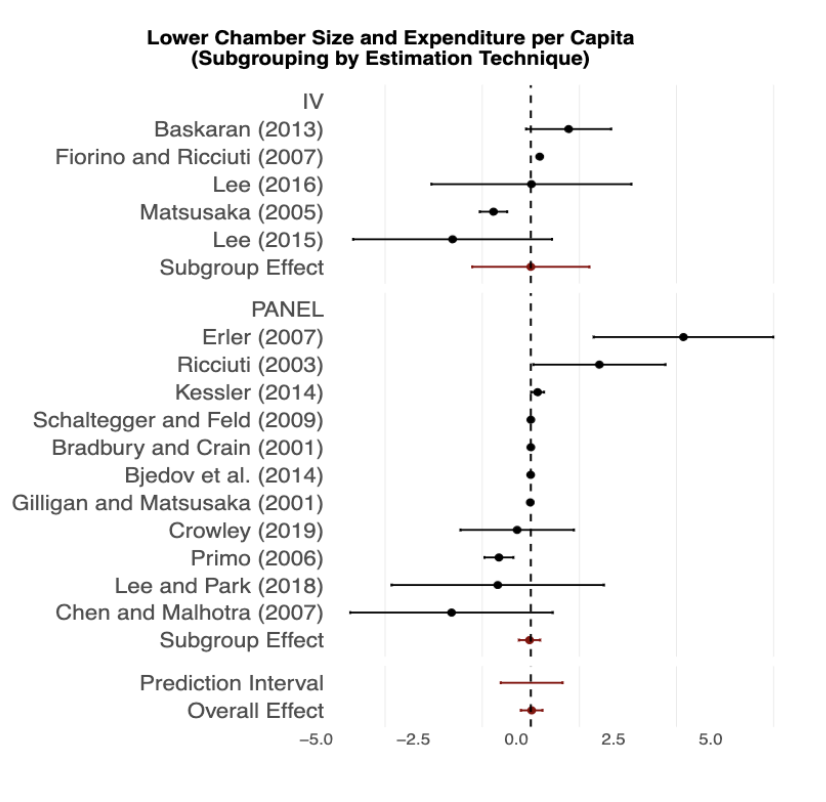

Source: [Freire et al (2022)](https://doi.org/10.1017/S0007123422000552)

## Fixed effects meta-analysis

- Assumption: All studies ($k=1, ..., K$) included in the analysis are estimating the exact same underlying true population treatment effect, $\tau$. Any variation in results is due purely to random sampling error
- Method: Calculate a pooled estimate ($ATE_{pooled}$) as a weighted average of the individual study estimates ($ATE_k$)
- Weighting: Each study’s contribution is weighted by its precision. Studies with smaller standard errors (higher precision) receive more weight

$$ATE_{pooled} = \frac{\sum_{k=1}^{K} w_k ATE_k}{\sum_{k=1}^{K} w_k} = \frac{\sum_{k=1}^{K} (ATE_k / SE_k^2)}{\sum_{k=1}^{K} (1 / SE_k^2)}$$

- Standard error of pooled estimate: The variance of the pooled estimate is the inverse of the sum of the precisions:

$$Var(ATE_{pooled}) = \frac{1}{\sum_{k=1}^{K} w_k} = \frac{1}{\sum_{k=1}^{K} (1 / SE_k^2)}$$

$$SE_{pooled} = \sqrt{Var(ATE_{pooled})}$$

- The resulting pooled standard error reflects the gain in precision from combining evidence

## When is fixed effects meta-analysis appropriate?

- This simple pooling method rests on several strong and often unrealistic assumptions:
  1. Homogeneity of Effect: All studies are estimating precisely the same true effect size $\tau$. There is no real variation in the effect across different populations, settings, or minor treatment variations
  2. Independence of Studies: The results of the studies are statistically independent (often violated if studies share researchers, settings, or are aware of each other)
  3. No Bias: Each individual study estimate ($ATE_k$) is assumed to be an unbiased estimate of the common true effect $\tau$. Potential biases (sampling, publication, etc.) are ignored
- These assumptions are particularly questionable when pooling studies across diverse contexts or designs
- These assumptions can be relaxed with more complex models:
  - Random effects meta-analysis: Assumes that the true effect size varies across studies, allowing for a distribution of effect sizes rather than a single common effect
  - Hierarchical models: Can model both within-study and between-study variability
- However, results can be heavily skewed by publication bias (the “file drawer problem”)
- Techniques exist to detect this (e.g., funnel plots) but cannot fully correct for it
- Let’s see how to conduct one in practice (all of it!)

# Case study: Legislature size and government spending 💰

## Step 01: Scrape data

- My colleagues and I conducted a meta-analysis of the effects of legislature size on government spending
- All information is available at https://github.com/danilofreire/legislature-size-meta-analysis
- To find the articles, we used Google Scholar (n = 1001); Microsoft Academic (n = 927); and Scopus (n = 736) and searched for the following keywords:
- `("upper chamber size" OR "lower chamber size" OR "council size" OR "parliament size" OR "legislature size" OR "number of legislators" OR "legislative size") AND ("spending" OR "expenditure" OR "government size")`
- We also searched all articles that cited the original work on the effects of legislature size on government spending, and ended up with 2664 records

[figure not shown]

Source: [Freire et al (2022)](https://doi.org/10.1017/S0007123422000552)

## Step 02: Extract data

- Then, we used the [PRISMA guidelines](https://www.prisma-statement.org/) to select the articles that met our inclusion criteria:
  - We selected only articles in English, and discarded duplicates, PhD theses, and book chapters
  - We excluded articles by title, then by abstract, then by full text (two independent coders)
  - The paper should (i) conduct a quantitative analysis, (ii) report data on the number of legislators, and (iii) also include data on public expenditure
- We then extracted all ATEs and standard errors from the articles to conduct two analyses:
  - One with the strictest model and one with all models
- We ended up with 30 articles (2 included manually), with 45 estimates in the strict sample, 162 in the complete sample

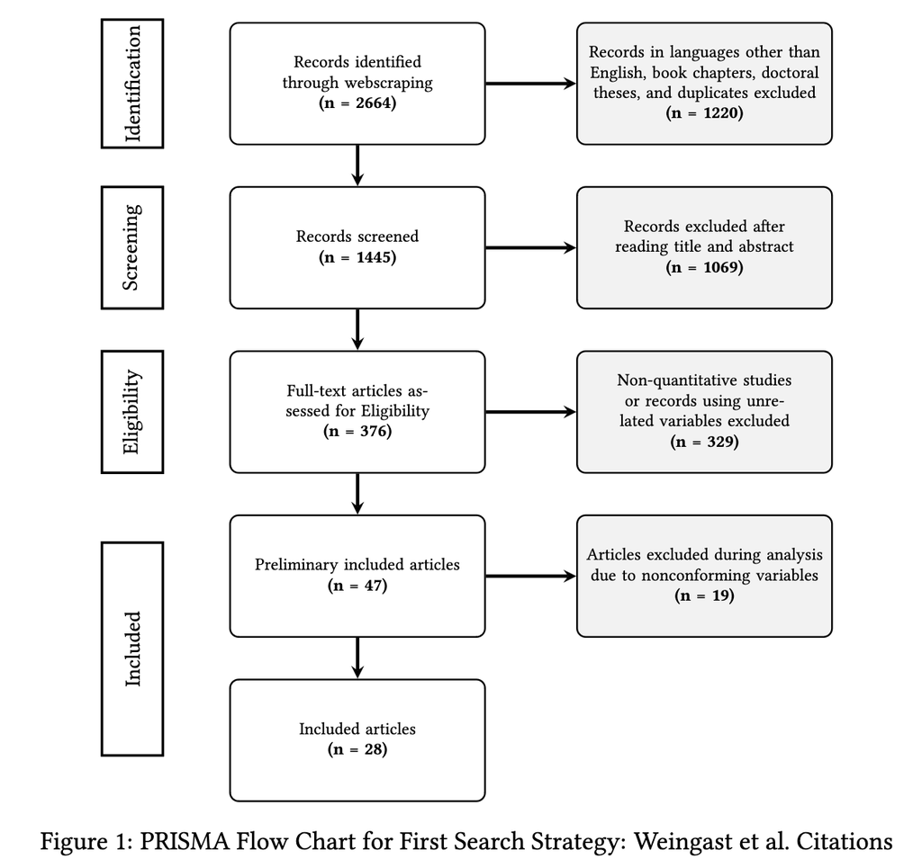

Part of the data extraction process

## Step 03: Collect moderators

- We believed that the effects of legislature size on government spending would be moderated by:
  - Independent variable (upper chamber size, lower chamber size, or council size)
  - Year
  - Methodology (OLS, RDD, IV, panel)
  - Publication (yes or no)
  - Institutional design (bicameralism, unicameralism, mixed)
  - Electoral system (majoritarian or proportional)
- These variables are useful to estimate meta-regression models, which allow us to estimate the effect of moderators on the ATE

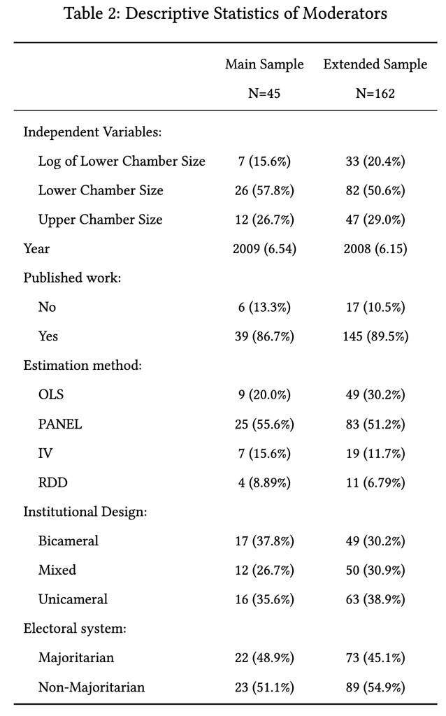

## Step 04: Conduct meta-analysis

- We used the [`meta`](https://cran.r-project.org/web/packages/meta/index.html) `R` package to conduct the meta-analysis
- Although we did estimate fixed effect models, the main models had random effects, which are more appropriate for our data
- Instead of having $\tau = \theta + \varepsilon$ (true effect + within study error), we assumed that $\theta$ varies across studies, having a true parameter $\mu$ and a between-study error $\xi_i$:

$$\tau = \mu + \xi_i + \varepsilon_i$$

- We found a lot of heterogeneity in the data!
- But the meta-regressions also helped us understand the main drivers of the differences in the ATE 🤓

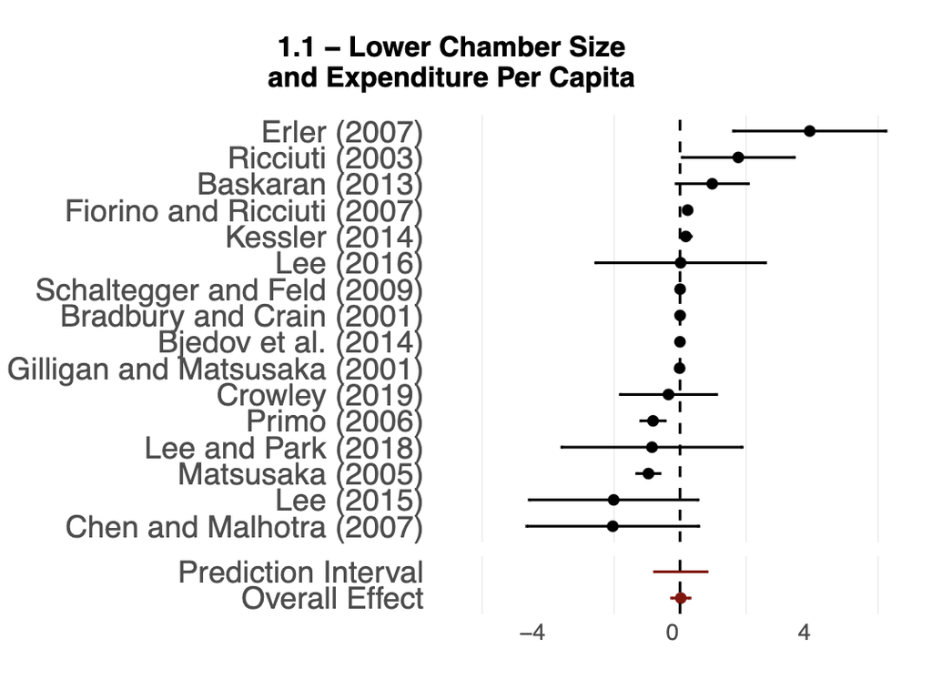

Here is one of the many figures we produced. As you can see, the main effect is close to zero and there is a lot of variability in the estimates

## Meta-regression

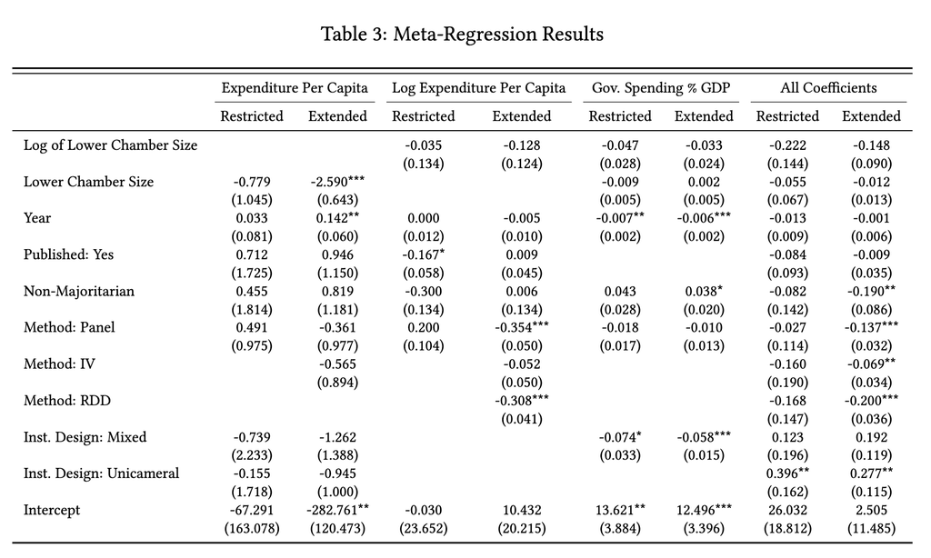

## Testing for method heterogeneity

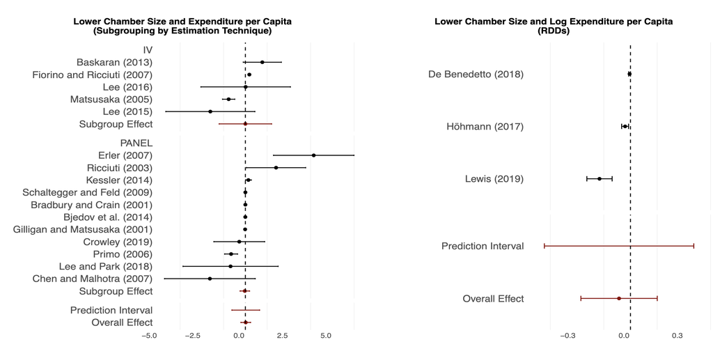

# Conclusion 📝

## Conclusion

- Generalising experimental findings is surely challenging, as it introduces uncertainty and the potential for bias
- It’s important to distinguish between the SATE (effect in the sample) and the PATE (effect in the target population). Estimating the PATE requires accounting for sampling variability
- Convenience sampling complicates PATE estimation and makes standard error calculation based on random sampling assumptions inappropriate
- The Bayesian framework offers a coherent way to integrate prior knowledge with new evidence and explicitly model uncertainty about potential biases
- Meta-analysis provides tools for pooling study results, but standard methods (like fixed effects) rely on strong, often unmet, assumptions (e.g., homogeneity of effects, no publication bias, no sampling bias)
- Statistical models facilitate interpolation and extrapolation but depend on correct specification
- Transparency about assumptions is important when integrating findings or extrapolating results